# CARPS Reproducibility Report

```r
articleID <- "4-1-2015_PS" # insert the article ID code here e.g., "10-3-2015_PS"
reportType <- 'final'
pilotNames <- "Sean Zion, Mufan Luo" # insert the pilot's name here e.g., "Tom Hardwicke". If there are multiple pilots enter both names in a character string e.g., "Tom Hardwicke, Bob Dylan"
copilotNames <- "Erica Yoon, Tom Hardwicke" # insert the co-pilot's name here e.g., "Michael Frank". If there are multiple co-pilots enter both names in a character string e.g., "Tom Hardwicke, Bob Dylan"
pilotTTC <- 500 # insert the pilot's estimated time to complete (in minutes, fine to approximate) e.g., 120
copilotTTC <- 220 # insert the co- pilot's estimated time to complete (in minutes, fine to approximate) e.g., 120
pilotStartDate <- as.Date("11/5/17", format = "%m/%d/%y") # insert the pilot's start date in US format e.g., as.Date("01/25/18", format = "%m/%d/%y")
copilotStartDate <- as.Date("10/19/18", format = "%m/%d/%y") # insert the co-pilot's start date in US format e.g., as.Date("01/25/18", format = "%m/%d/%y")
completionDate <- as.Date("06/12/19", format = "%m/%d/%y") # copilot insert the date of final report completion (after any necessary rounds of author assistance) in US format e.g., as.Date("01/25/18", format = "%m/%d/%y")
```

#### Target outcomes:

> We complemented our by-face analysis with a by-participant repeated measures analysis of variance (ANOVA) with DFT as a repeated measure and judgment type (trustworthiness vs. attractiveness) as a between-subjects factor. The observed effects supported the same conclusions as the by-face analysis. The main effect of DFT was significant, F(10, 37) = 4.05, p < .001, ηp2 = .52. More important, this main effect was qualified by a significant interaction, F(10, 37) = 5.95, p < .001, ηp2 = .62.

> Fig.2

## Step 1: Load packages

```r
library(tidyverse) # for data munging
library(knitr) # for kable table formating
library(haven) # import and export 'SPSS', 'Stata' and 'SAS' Files
library(readxl) # import excel files
library(ReproReports) # custom report functions
library(ggplot2)
library(psych)
library(corrplot)
library(car)
library(ez) #For ANOVA Models
library(afex) #to run aov_ez
```

```r
# Prepare report object. This will be updated automatically by the reproCheck function each time values are compared.
reportObject <- data.frame(dummyRow = TRUE, reportedValue = NA, obtainedValue = NA, valueType = NA, percentageError = NA, comparisonOutcome = NA, eyeballCheck = NA)
```

## Step 2: Load data

```r
faces <- read.csv("data/Experiment _1_Rps _v2.csv")
```

## Step 3: Tidy data

```r
faces$subid <- c(1:48) #adding a new column for subject ID

faces_tidy <- faces %>%
  gather(key="DFT_Rating", value, 3:35) %>%
  separate(DFT_Rating, c("dft", "value_trial"), sep="T_") %>%
  separate(value_trial, c("dft_value", "trial_num"), sep="_") %>%
  mutate(trial_num = paste("trial", trial_num, sep="")) %>%
  mutate(dft_value = as.numeric(dft_value)) %>%
  mutate(trust_attract = fct_recode(factor(Trust1Attrc0), "trust" = "1", "attractive" = "0")) %>%
  select(-dft, -Trust1Attrc0)
```

## Step 4: Run analysis

### Pre-processing

```r
faces_prepr <- faces_tidy %>%
  spread(trial_num, value) %>%
  transmute(subid, dft_value, trust_attract,
            avg_value = rowMeans(select(., trial1:trial3))) %>%
  mutate(trust_attract = factor(trust_attract),
         dft_value = factor(dft_value),
         subid = factor(subid))
```

### Descriptive statistics

```r
#Mean and SD for ratings across judement type (trustworthy / attractiveness)
desc_stat <- faces_tidy %>%
  group_by(trust_attract, dft_value) %>%
  dplyr::summarise(mean = mean(value), sd = sd(value)) %>%
  gather(stat, value, -trust_attract, -dft_value) %>%
  unite(judg_stat, trust_attract, stat) %>%
  spread(judg_stat, value)

print(desc_stat)
```

```
## # A tibble: 11 x 5
##    dft_value attractive_mean attractive_sd trust_mean trust_sd
##        <dbl>           <dbl>         <dbl>      <dbl>    <dbl>
##  1         0            4.32          1.54       6.28     1.58
##  2        10            4.72          1.47       6.33     1.37
##  3        20            5.21          1.53       6.47     1.29
##  4        30            5.79          1.57       6.39     1.24
##  5        40            6.21          1.73       6.15     1.29
##  6        50            6.69          1.53       6.12     1.42
##  7        60            7.04          1.63       5.89     1.34
##  8        70            7.28          1.59       5.56     1.52
##  9        80            7.58          1.49       5.49     1.54
## 10        90            7.53          1.45       5.07     1.57
## 11       100            7.54          1.55       5.06     1.63
```

### Figure 2 Replication:

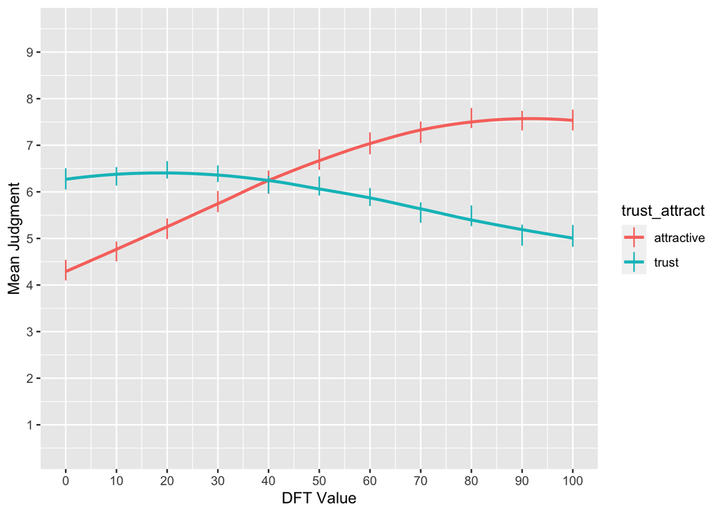

```r
#Figure 2 Replication

faces_tidy %>%
  mutate(dft_value = as.numeric(as.character(dft_value))) %>%
  group_by(trust_attract, dft_value) %>%
  dplyr::summarise(mean = mean(value), sd = sd(value)) %>%
  mutate(ci_lower = mean - sd/sqrt(48),
         ci_upper = mean + sd/sqrt(48)) %>%
  ggplot(., aes(x = dft_value, y=mean, col=trust_attract)) +
  geom_smooth(aes(group=trust_attract), se=F) +
  geom_linerange(aes(ymin = ci_lower, ymax = ci_upper)) +
  xlab('DFT Value') +
  ylab('Mean Judgment') +
  scale_y_continuous(limits= c(0.5, 9.5), breaks=seq(0,10,1)) +
  scale_x_continuous(breaks=seq(0,100,10))
```

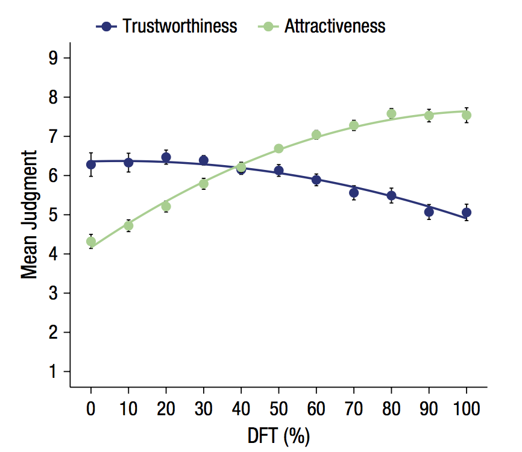

Original Figure 2

### Inferential statistics

> by-participant repeated measures analysis of variance (ANOVA) with DFT as a repeated measure and judgment type (trustworthiness vs. attractiveness) as a between-subjects factor. The observed effects supported the same conclusions as the by-face analysis. The main effect of DFT was significant, F(10, 37) = 4.05, p < .001, ηp2 = .52. More important, this main effect was qualified by a significant interaction, F(10, 37) = 5.95, p < .001, ηp2 = .62.

Our goal was to reproduce the analysis of the authors in experiment one. We conducted a by-participant repeated measures analysis of variance using the value of DFT as a repeated measure and judgment type (either trustworthiness or attractiveness) as a between-subjects factor. We tried several different ways of specifying the analysis.

### Model 1:

```r
#Model 1 - Repeated Measures ANOVA
model1 <- with(faces_prepr, aov(avg_value ~ (dft_value * trust_attract) + Error(subid / (dft_value))))
model1_summary <- summary(model1)
model1_summary
```

```
##
## Error: subid
##               Df Sum Sq Mean Sq F value Pr(>F)
## trust_attract  1   28.5   28.50   2.428  0.126
## Residuals     46  540.0   11.74
##
## Error: subid:dft_value
##                          Df Sum Sq Mean Sq F value  Pr(>F)
## dft_value                10   78.5    7.85   10.50 4.6e-16 ***
## dft_value:trust_attract  10  327.1   32.71   43.75 < 2e-16 ***
## Residuals               460  343.9    0.75
## ---
## Signif. codes:  0 '***' 0.001 '**' 0.01 '*' 0.05 '.' 0.1 ' ' 1
```

### Model 2:

```r
#Model 2 - Repeated Measures ANOVA
model2 <- ezANOVA(data = faces_prepr, dv = .(avg_value), wid = .(subid), within = .(dft_value), between = .(trust_attract), detailed = TRUE, return_aov=T)

model2$ANOVA
```

```
##                    Effect DFn DFd         SSn      SSd          F            p
## 1             (Intercept)   1  46 19800.08418 539.9832 1686.72642 6.705597e-38
## 2           trust_attract   1  46    28.49832 539.9832    2.42771 1.260611e-01
## 3               dft_value  10 460    78.48064 343.8965   10.49766 4.597896e-16
## 4 trust_attract:dft_value  10 460   327.05724 343.8965   43.74757 1.213988e-60
##   p<.05        ges
## 1     * 0.95726740
## 2       0.03123521
## 3     * 0.08155017
## 4     * 0.27008612
```

### Model 3 (Added by co-pilot):

```r
model3 <- aov_ez(data = faces_prepr,
       id = "subid",
       between = "trust_attract",
       dv = "avg_value",
       within = c("dft_value"),
       anova_table = list(correction = 'none', es = 'pes'))

print(model3)
```

```
## Anova Table (Type 3 tests)
##
## Response: avg_value
##                    Effect      df   MSE         F  pes p.value
## 1           trust_attract   1, 46 11.74      2.43 .050    .126
## 2               dft_value 10, 460  0.75 10.50 *** .186   <.001
## 3 trust_attract:dft_value 10, 460  0.75 43.75 *** .487   <.001
## ---
## Signif. codes:  0 '***' 0.001 '**' 0.01 '*' 0.05 '+' 0.1 ' ' 1
```

```r
# TOM SANITY CHECK - CONCURS WITH OUR PREVIOUS EFFORTS
faces_forAOV <- faces_tidy %>% mutate(subid = as.factor(subid), dft_value = as.factor(dft_value)) %>% group_by(subid, dft_value, trust_attract) %>% summarize(avg = mean(value))

thisAov <- aov(avg ~ trust_attract*dft_value + Error(subid/dft_value), data=faces_forAOV)
summary(thisAov)
```

```
##
## Error: subid
##               Df Sum Sq Mean Sq F value Pr(>F)
## trust_attract  1   28.5   28.50   2.428  0.126
## Residuals     46  540.0   11.74
##
## Error: subid:dft_value
##                          Df Sum Sq Mean Sq F value  Pr(>F)
## dft_value                10   78.5    7.85   10.50 4.6e-16 ***
## trust_attract:dft_value  10  327.1   32.71   43.75 < 2e-16 ***
## Residuals               460  343.9    0.75
## ---
## Signif. codes:  0 '***' 0.001 '**' 0.01 '*' 0.05 '.' 0.1 ' ' 1
```

All models concur with each other but don’t match the reported outcomes.

At this stage we contacted the original authors for assistance. They correctly pointed out that we had missed an important footnote (footnote 2) which read: The sphericity assumption for this analysis and the corresponding analysis in Experiments 2 and 3 was not met. We report multivariate test results, as recommended by Maxwell and Delaney (2004), because these tests are more optimal than correcting for sphericity. The pattern of results did not differ depending on whether we used either a multivariate test or sphericity correction." They also sent SPSS syntax and a screenshot of the output - which demonstrates successful reproduction of the target outcomes (see below):

GLM DFT_100 DFT_90 DFT_80 DFT_70 DFT_60 DFT_50 DFT_40 DFT_30 DFT_20 DFT_10 DFT_00 BY Trust1Attrc0 /WSFACTOR=factor1 11 Polynomial /METHOD=SSTYPE(3) /PRINT=ETASQ /CRITERIA=ALPHA(.05) /WSDESIGN=factor1 /DESIGN=Trust1Attrc0.

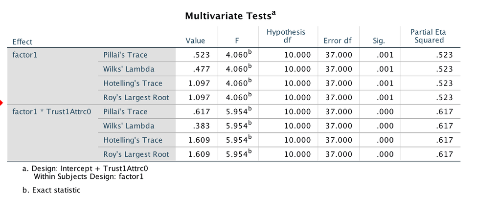

Unfortunately at this time our team does not have access to SPSS nor the expertise to implement these multivariate tests in R - the analysis appears to beyond our operational definition of a ‘reasonably straightforward analysis’. We have decided to classify this case as a ‘reproducible with author assistance’ - but it should be noted that we have not verified this in an independent analysis.

### Recording differences

```r
# Main effect of DFT:

#Output - Main Effect of DFT
reportObject <- reproCheck(reportedValue = "4.05", obtainedValue = 4.06, valueType = 'F')
```

```
## [1] "MINOR_ERROR for F. The reported value (4.05) and the obtained value (4.06) differed by 0.25%. Note that the obtained value was rounded to 2 decimal places to match the reported value."
```

```r
#Output - num df
reportObject <- reproCheck(reportedValue = "10", obtainedValue = 10, valueType = 'df')
```

```
## [1] "MATCH for df. The reported value (10) and the obtained value (10) differed by 0%. Note that the obtained value was rounded to 0 decimal places to match the reported value."
```

```r
#Output - den df
reportObject <- reproCheck(reportedValue = "37", obtainedValue = 37, valueType = 'df')
```

```
## [1] "MATCH for df. The reported value (37) and the obtained value (37) differed by 0%. Note that the obtained value was rounded to 0 decimal places to match the reported value."
```

```r
#Output - p value
reportObject <- reproCheck(reportedValue = "<.001", obtainedValue = "<.001", valueType = 'p', eyeballCheck = TRUE)
```

```
## [1] "MATCH for p. Eyeball comparison only."
```

```r
#Output - pes value
reportObject <- reproCheck(reportedValue = ".52", obtainedValue = .523, valueType = 'pes')
```

```
## [1] "MATCH for pes. The reported value (0.52) and the obtained value (0.52) differed by 0%. Note that the obtained value was rounded to 2 decimal places to match the reported value."
```

```r
# Interaction:

#Output - Interaction Effect of DFT with Judgment Type
reportObject <- reproCheck(reportedValue = "5.95", obtainedValue = 5.95, valueType = 'F')
```

```
## [1] "MATCH for F. The reported value (5.95) and the obtained value (5.95) differed by 0%. Note that the obtained value was rounded to 2 decimal places to match the reported value."
```

```r
#Output - num df
reportObject <- reproCheck(reportedValue = "10", obtainedValue = 10, valueType = 'df')
```

```
## [1] "MATCH for df. The reported value (10) and the obtained value (10) differed by 0%. Note that the obtained value was rounded to 0 decimal places to match the reported value."
```

```r
#Output - den df
reportObject <- reproCheck(reportedValue = "37", obtainedValue = 37, valueType = 'df')
```

```
## [1] "MATCH for df. The reported value (37) and the obtained value (37) differed by 0%. Note that the obtained value was rounded to 0 decimal places to match the reported value."
```

```r
#Output - p value
reportObject <- reproCheck(reportedValue = "<.001", obtainedValue = "<.001", valueType = 'p', eyeballCheck = TRUE)
```

```
## [1] "MATCH for p. Eyeball comparison only."
```

```r
#Output - pes value
reportObject <- reproCheck(reportedValue = ".62", obtainedValue = .617, valueType = 'pes')
```

```
## [1] "MATCH for pes. The reported value (0.62) and the obtained value (0.62) differed by 0%. Note that the obtained value was rounded to 2 decimal places to match the reported value."
```

## Step 5: Conclusion

We initially could not reproduce some degrees of freedom and F-values despite trying multiple different model specifications. We contacted the authors for assistance and recieved a reply. They correctly pointed out that we had missed an important footnote (footnote 2) which read: “The sphericity assumption for this analysis and the corresponding analysis in Experiments 2 and 3 was not met. We report multivariate test results, as recommended by Maxwell and Delaney (2004), because these tests are more optimal than correcting for sphericity. The pattern of results did not differ depending on whether we used either a multivariate test or sphericity correction.” They also sent SPSS syntax and a screenshot of the output - which demonstrated successful reproduction of the target outcomes.

Unfortunately at this time our team does not have access to SPSS nor the expertise to implement these multivariate tests in R - the analysis appears to be beyond our operational definition of a ‘reasonably straightforward analysis’. We have decided to classify this case as a ‘reproducible with author assistance’ - but it should be noted that we have not verified this in an independent analysis.

```r
Author_Assistance = TRUE # was author assistance provided? (if so, enter TRUE)

Insufficient_Information_Errors <- 0 # how many discrete insufficient information issues did you encounter?

# Assess the causal locus (discrete reproducibility issues) of any reproducibility errors. Note that there doesn't necessarily have to be a one-to-one correspondance between discrete reproducibility issues and reproducibility errors. For example, it could be that the original article neglects to mention that a Greenhouse-Geisser correct was applied to ANOVA outcomes. This might result in multiple reproducibility errors, but there is a single causal locus (discrete reproducibility issue).

locus_typo <- 0 # how many discrete issues did you encounter that related to typographical errors?
locus_specification <- 0 # how many discrete issues did you encounter that related to incomplete, incorrect, or unclear specification of the original analyses?
locus_analysis <- 0 # how many discrete issues did you encounter that related to errors in the authors' original analyses?
locus_data <- 0 # how many discrete issues did you encounter that related to errors in the data files shared by the authors?
locus_unidentified <- 1 # how many discrete issues were there for which you could not identify the cause

# How many of the above issues were resolved through author assistance?
locus_typo_resolved <- 0 # how many discrete issues did you encounter that related to typographical errors?
locus_specification_resolved <- 0 # how many discrete issues did you encounter that related to incomplete, incorrect, or unclear specification of the original analyses?
locus_analysis_resolved <- 0 # how many discrete issues did you encounter that related to errors in the authors' original analyses?
locus_data_resolved <- 0 # how many discrete issues did you encounter that related to errors in the data files shared by the authors?
locus_unidentified_resolved <- 1 # how many discrete issues were there for which you could not identify the cause

Affects_Conclusion <- FALSE # Do any reproducibility issues encounter appear to affect the conclusions made in the original article? This is a subjective judgement, but you should taking into account multiple factors, such as the presence/absence of decision errors, the number of target outcomes that could not be reproduced, the type of outcomes that could or could not be reproduced, the difference in magnitude of effect sizes, and the predictions of the specific hypothesis under scrutiny.
```

```r
reportObject <- reportObject %>%
  filter(dummyRow == FALSE) %>% # remove the dummy row
  select(-dummyRow) %>% # remove dummy row designation
  mutate(articleID = articleID) %>% # add the articleID
  select(articleID, everything()) # make articleID first column

# decide on final outcome
if(any(!(reportObject$comparisonOutcome %in% c("MATCH", "MINOR_ERROR"))) | Insufficient_Information_Errors > 0){
  finalOutcome <- "Failure without author assistance"
  if(Author_Assistance == T){
    finalOutcome <- "Failure despite author assistance"
  }
}else{
  finalOutcome <- "Success without author assistance"
  if(Author_Assistance == T){
    finalOutcome <- "Success with author assistance"
  }
}

# collate report extra details
reportExtras <- data.frame(articleID, pilotNames, copilotNames, pilotTTC, copilotTTC, pilotStartDate, copilotStartDate, completionDate, Author_Assistance, finalOutcome, Insufficient_Information_Errors, locus_typo, locus_specification, locus_analysis, locus_data, locus_unidentified, locus_typo_resolved, locus_specification_resolved, locus_analysis_resolved, locus_data_resolved, locus_unidentified_resolved)

# save report objects
if(reportType == "pilot"){
  write_csv(reportObject, "pilotReportDetailed.csv")
  write_csv(reportExtras, "pilotReportExtras.csv")
}

if(reportType == "final"){
  write_csv(reportObject, "finalReportDetailed.csv")
  write_csv(reportExtras, "finalReportExtras.csv")
}
```